[← Culture Voyager 목차](https://waterfirst.github.io/culture-voyager/)

# 프라하 — 카프카의 도시를 걷다

Culture Voyager | 골목마다 문학이 살아있는 보헤미아의 수도. 맥주 한 잔과 함께.

Author

Nakcho Choi

Published

May 18, 2026

## 어느 아침, 카를교 위에서

새벽 5시 30분. 카를교(Karlův most) 위에 안개가 낮게 깔린다.

낮이면 수천 명이 밀려드는 이 다리가 이 시간엔 당신 것이다. 30개의 성인 석상이 안개 속에서 윤곽만 드러내고, 블타바 강(Vltava) 위로 프라하 성의 실루엣이 떠오른다. 이 순간을 본 사람은 안다 — **프라하는 새벽에 가장 정직하다.**

카프카는 이 도시에 대해 이렇게 말했다. “프라하는 놓아주지 않는다. 이 어머니에겐 발톱이 있다.” 그리고 그 말은 사실이다. 한 번 발을 들인 사람은 계속 돌아온다. 이유를 설명하기 어렵다. 그냥… 이 도시의 리듬에 중독되는 거다.

맥주 한 잔에 2천 원. 골목마다 고딕과 바로크가 뒤섞인 건축. 세상에서 가장 아름다운 도서관. 그리고 곳곳에 스며있는 카프카의 그림자.

오늘은 그 도시를 걷자.

## 왜 프라하인가: 문학과 맥주의 도시

### 천 년 도시의 겹겹이 쌓인 시간

프라하는 한 번도 대규모 폭격을 당한 적이 없다. 그래서 로마네스크, 고딕, 르네상스, 바로크, 아르누보가 한 거리에 공존한다. 걷는 것만으로 건축사 수업을 듣는 셈이다.

1348년 카를 4세가 세운 카를대학(현존하는 중유럽 최초의 대학), 모차르트가 돈 조반니를 초연한 에스테이트 극장, 카프카가 태어나고 죽을 때까지 떠나지 못한 구시가. 이 도시는 **유럽 지성사의 교차로**다.

### 맥주의 나라, 체코

체코는 1인당 맥주 소비량 세계 1위다. 28년 연속. 이건 통계가 아니라 **문화**다. 필스너 우르켈(Pilsner Urquell)의 본향이 바로 체코 플젠(Plzeň)이고, 프라하의 펍에서 생맥주 한 잔은 물보다 싸다. 과장이 아니다. 레스토랑 메뉴판을 보면 맥주 500ml가 물 500ml보다 저렴한 경우가 실제로 있다.

## 3일 추천 코스

### Day 1: 구시가지 — 카프카와 맥주의 하루

**아침 (08:00)**: 구시가지 광장(Staroměstské náměstí)에서 시작. 천문시계(올로이) 앞에 서면 1410년부터 작동 중인 시계가 매시 정각에 12사도의 행렬을 보여준다. 600년 동안 매일.

**오전 (09:30)**: 카프카 생가(Náměstí Franze Kafky). 마이젤로바 거리와 카프로바 거리의 모퉁이. 1883년 7월 3일, ’탑의 집’이라 불리던 이곳에서 프란츠 카프카가 태어났다. 지금은 작은 기념관과 함께 광장 이름 자체가 ’프란츠 카프카 광장’이다.

**점심 (12:00)**: 우 핀카수(U Pinkasů). 1843년 개업, 프라하 최초로 필스너 우르켈을 판매한 전설적인 펍. 스비치코바(Svíčková, 크림소스 소고기)와 크네들리키(빵 만두)를 시키고, 탱크에서 직접 따르는 생맥주를 곁들인다. 감동적이다.

**오후 (14:00)**: 카프카 박물관(Franz Kafka Museum). 말라 스트라나의 블타바 강변, 헤르게트 벽돌공장 건물을 개조한 이 박물관은 카프카의 원고, 일기, 사진, 그리고 그의 내면세계를 형상화한 오디오비주얼 설치물로 가득하다. 어둡고 미로 같은 전시 동선 자체가 카프카의 소설 같다.

**저녁 (18:00)**: 레트나 비어 가든(Letná Beer Garden). 블타바 강 북쪽 언덕 위 공원의 야외 맥주집. 프라하 구시가 전체가 파노라마로 펼쳐진다. 해질 무렵, 카를교와 프라하 성이 황금빛으로 물드는 순간 — 맥주 한 잔이면 완벽하다.

### Day 2: 프라하 성 — 천 년 권력의 언덕

**아침 (08:00)**: 프라하 성(Pražský hrad). 세계에서 가장 큰 고대 성곽 단지. 오전 개장 직후가 가장 한산하다. 성 비투스 대성당의 스테인드글라스 — 그중 알폰스 무하(Mucha)가 디자인한 창이 있다. 아르누보의 거장이 성당 창에 남긴 서명.

**오전 (10:00)**: 황금소로(Zlatá ulička). 16세기 연금술사들이 살았다는 전설의 골목. 22번지 — 카프카가 1916~1917년 겨울, 여동생의 집을 빌려 글을 썼던 곳. 작고 푸른 문을 열면 한 사람이 겨우 들어갈 공간. 여기서 카프카는 단편집 《시골 의사》를 집필했다.

**점심 (12:30)**: 스트라호프 수도원 양조장(Klášterní pivovar Strahov). 프라하 성 뒤편 언덕의 수도원 안 양조장. 800년 된 수도원에서 수도사들이 만든 맥주를 마신다. 성 노르베르트 IPA를 추천한다. 그리고 그 건너편 스트라호프 도서관 — 세상에서 가장 아름다운 도서관 중 하나. 바로크식 천장 프레스코화 아래 중세 장서가 빼곡하다.

**오후 (14:30)**: 말라 스트라나를 천천히 걷자. 좁은 골목, 자갈길, 벽에 새겨진 성모상, 아르누보 카페. 이 동네는 관광객용이 아니다. 실제로 사람이 산다. 그래서 좋다.

**저녁 (19:00)**: 브레도브스키 드부르(Bredovský Dvůr). 꼴레뇨(Koleno) — 돼지 무릎을 오븐에서 천천히 구운 요리. 겉은 캐러멜처럼 바삭, 속은 녹을 듯 촉촉. 필스너 우르켈과 함께. 이게 체코 남자들의 ’소울 푸드’다.

### Day 3: 블타바 강변 — 느리게, 더 느리게

**아침 (06:00)**: 카를교 일출. 이건 필수다. 프라하를 사진으로 남기고 싶다면, 이른 아침 카를교만한 곳이 없다. 30개의 바로크 성인상 사이로 프라하 성에 첫 햇살이 닿는 순간.

**오전 (09:00)**: 비셰흐라드(Vyšehrad) 성채. 관광객 90%가 모르는 곳. 구시가에서 트램으로 10분이면 닿는다. 이 언덕 위 묘지에 드보르자크, 스메타나, 무하 등 체코의 위인들이 잠들어 있다. 성벽 위에서 내려다보는 블타바 강의 곡선이 아름답다.

**점심 (12:00)**: 비노흐라디(Vinohrady) 동네. 관광객이 거의 없는 프라하 현지인들의 카페 거리. 브런치 카페 Eska나 카페 Sladkovský에서 느긋한 점심.

**오후 (14:00)**: 시립 도서관 앞의 ‘책의 탑’ 설치미술 감상 후, 하벨 시장(Havelské tržiště)에서 기념품 쇼핑. 그리고 마지막으로 — 블타바 강변 벤치에 앉아서 아무것도 안 하기. 이것이 프라하식 여행의 완성이다.

## 카프카의 프라하: 문학 산책

카프카는 1883년 프라하에서 태어나 1924년 사망할 때까지 — 잠깐의 베를린 체류를 제외하면 — 평생을 이 도시에서 보냈다. 그리고 평생 이 도시를 사랑하면서도 증오했다.

> “프라하는 놓아주지 않는다. 우리 둘 중 누구든, 이 어머니에겐 발톱이 있다.”

그의 소설 속 미로 같은 관료제, 출구 없는 공간, 끝없이 반복되는 복도 — 이것들은 프라하 구시가의 지형 그 자체다. 좁은 골목을 걷다 보면 불현듯 카프카의 K가 된 기분이 든다. 어디로 가야 할지 모르겠는데, 어딘가로 가고 있는.

**카프카 문학 산책 루트:**

1. 카프카 생가(프란츠 카프카 광장)
2. 구시가지 광장 킨스키 궁전(아버지의 가게가 1층에 있었다)
3. 골츠-킨스키 궁전 뒤 독일어 김나지움(카프카의 학교)
4. 황금소로 22번지(집필 공간)
5. 카프카 박물관(말라 스트라나)
6. 신유대인 묘지(카프카의 무덤, 3구역 21열)

## 🎬 프라하를 느끼는 영상

### 카프카 박물관 투어

[video not shown]

### 프라하 성과 카를교 드론 영상

[video not shown]

## 🎵 프라하를 위한 플레이리스트

스메타나의 “나의 조국 — 블타바(Moldau)”로 시작해서, 재즈와 카페 뮤직으로 이어지는 프라하 감성 리스트.

[interactive chart not shown]

## 📊 데이터로 보는 프라하

### 유럽 주요 도시 1일 여행 비용 비교

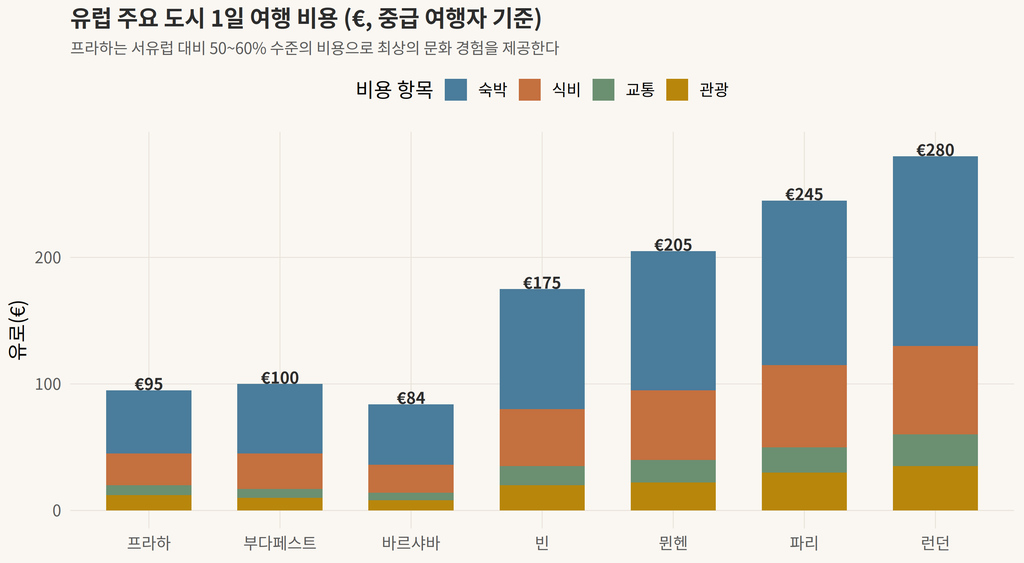

### 프라하 월별 관광객 수와 추천 여행 시기

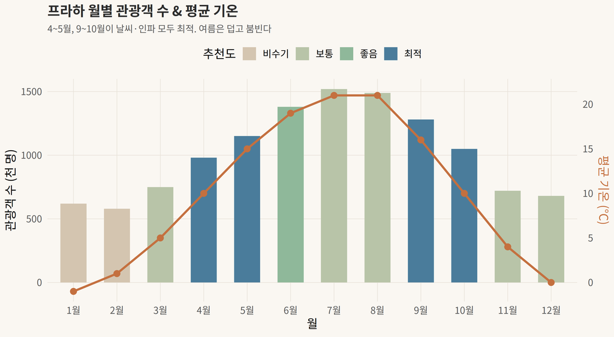

### 체코 맥주: 세계 1위의 맥주 문화

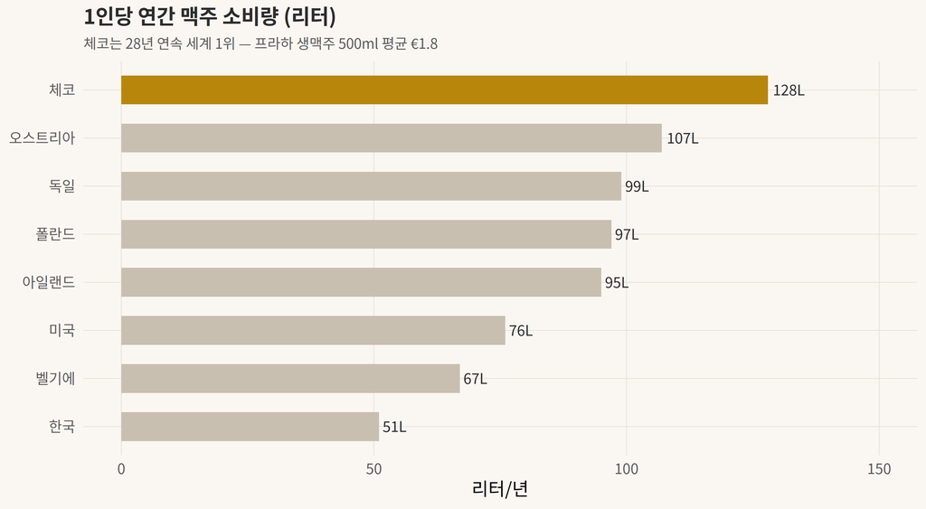

## 실전 여행 정보

### 예산 가이드 (2026년 기준, 1인)

|  | 절약형 | 중급 | 럭셔리 |
| --- | --- | --- | --- |
| **숙박** | €25~35 (호스텔) | €50~80 (3성급) | €120+ (부티크) |
| **식비** | €15~20 | €25~40 | €60+ |
| **교통** | €5 (도보+트램) | €8 (일일권) | €20 (택시) |
| **관광** | €10 | €15~25 | €40+ |
| **맥주** | €3 (3잔!) | €5 | €10 |
| **1일 합계** | **€58~73** | **€98~158** | **€250+** |

### 꼭 알아야 할 팁

🍺 **맥주 주문법**: “Jedno pivo, prosím”(예드노 피보, 프로심) = 맥주 한 잔 주세요. 이것만 알면 프라하 어디서든 환영받는다.

🚃 **교통**: 24시간 패스(120 CZK, 약 €5)면 트램·지하철·버스 무제한. 프라하는 걷기 좋은 도시라 구시가만 돌아다닌다면 대중교통 없이도 충분하다.

📸 **사진 골든타임**: 카를교 일출(여름 5:30, 겨울 7:30), 프라하 성 야경(일몰 후 30분), 레트나 공원 석양.

🏨 **숙소 추천 지역**: 비노흐라디(Vinohrady) — 구시가에서 트램 10분, 현지인 동네라 물가 착하고 분위기 좋다. 스타레 므네스토(구시가)는 비싸고 시끄럽다.

## 프라하가 남기는 것

사흘이면 프라하를 “봤다”고 말할 수 있을까? 아마 아닐 거다.

하지만 이건 말할 수 있다. 카를교 위 새벽 안개를 걸어본 사람은, 그 안개 속에서 600년 된 석상이 눈을 깜빡이는 것 같은 착각을 해본 사람은, **어딘가에 돌아갈 곳이 있다는 안도감**을 얻는다.

카프카는 평생 프라하를 떠나지 못했다. 떠나고 싶었지만, 결국 못 떠났다. 그건 약함이 아니라 솔직함이었을지도 모른다. 어떤 도시는 단순히 ‘좋아서’ 돌아가는 게 아니다. 그 도시가 내 일부가 되어버려서, 떠나는 게 불가능해지는 것이다.

프라하가 그런 도시다. 조심하시라.

**다음 여행지 예고**

다음 E축 콘텐츠에서는 **아이슬란드 — 지구의 날것**을 다룹니다. 빙하, 화산, 오로라, 간헐천. 가장 원시적이고 가장 경이로운 풍경을 만나러 갑니다.

*Culture Voyager는 매주 일요일 새로운 여행 이야기를 전합니다.*